# Intrinsic Potential for Chinook Salmon — Klamath Basin

Maddee Wiggins (FlowWest)

2026-05-06

## Objective

Estimate the intrinsic potential (IP) for fall Chinook salmon spawning across the Klamath Basin stream network. Following Bjorkstedt et al. (2005), IP is modeled at two scales:

- **IP_reach** — a reach-level geometric mean of three physical suitability scores (gradient, discharge, and valley confinement), structured as a limiting-factors analysis in which very low suitability on any single variable greatly reduces the overall score regardless of the other two.
- **IP-km** — a watershed-level metric equal to the length-weighted sum of IP_reach across all accessible reaches, expressing a watershed’s expected equivalent length of continuous high-quality habitat.

All reaches are evaluated regardless of survey coverage, treating the absence of fish observations as a gap in knowledge rather than evidence of absence.

### Literature Context

| Paper | Species | Study Area | IP Variables | IP Calculation |
| --- | --- | --- | --- | --- |
| Agrawal et al. (2005) | Coho salmon (juvenile), winter steelhead (juvenile), fall-run Chinook salmon (juvenile) | Northern California (Cape Blanco, OR to Monterey Bay, CA) | Channel gradient, valley constraint, mean annual discharge | Geometric mean of three suitability scores (0–1 scale) |
| Beechie et al. (2006) | Not species-specific — focused on channel–floodplain dynamics relevant to salmonids | Pacific Coastal Forest, Pacific Northwest (Puget trough and adjacent ranges) | Channel slope, discharge (2-yr flood), channel confinement (valley width:bankfull width ratio) | Stepwise predictive model classifying channel pattern (straight, meandering, island-braided, braided); no IP score per se |
| Connor et al. (2015) | Chinook salmon (spawning and rearing) | Skagit River basin, Washington | Multiple regression: drainage area, channel length, forest canopy, mean basin slope; IP model: stream gradient, stream width, mean basin elevation | Geometric mean of three IP suitability scores; Reach IP = IP score × accessible channel length |
| Busch et al. (2013) | Fall Chinook salmon (spawning) | Lower Columbia River ESU (22 populations) | Channel confinement (valley width:bankfull width), channel width, channel gradient | Geometric mean of three suitability scores; population IP = Σ(reach IP score × reach length) |
| Burnett et al. (2007) | Coho salmon (juvenile rearing), steelhead (juvenile rearing) | Coastal Province of Oregon (~2.5 million ha) | Mean annual stream flow, valley constraint (valley-width index), channel gradient | Geometric mean of three species-specific index scores (0–1); high IP threshold ≥0.75 |
| Bjorkstedt et al. (2005) | Coho salmon (CCC ESU), Chinook salmon (fall- and spring-run, CC ESU), Steelhead (NC and CCC ESUs); spawning and rearing habitat modeled for coho and steelhead; spawning only for Chinook | North-Central California Coast Recovery Domain (NCCCRD); multiple basins spanning the Central California Coast and Northern California Coast ESUs | Channel gradient, valley constraint (valley floor width / active channel width), mean annual discharge; species-specific suitability curves (Burnett et al. 2003, Agrawal et al. 2005) | Geometric mean of three suitability scores (0–1); reach scale ~50–200 m; limiting-factors structure (a low score in any one variable substantially reduces overall IP) |
| Ramos & Ward (2023) | Coho salmon (Oncorhynchus kisutch), Southern Oregon/Northern California Coast ESU; juvenile summer rearing habitat (primary focus) and spawning habitat | Six Klamath River tributaries (CA/OR) above Iron Gate Dam within the historic coho distribution: Scotch, Camp, Jenny, Fall, Shovel, and Spencer creeks | Mean annual discharge (estimated via regression for ungaged sites), channel gradient, valley constraint; suitability curves from Agrawal et al. (2005) | Geometric mean of three suitability scores (0–1); reach lengths 160–810 m (shorter reaches in steeper gradient); weighted IP-km = reach length × IP score, summed per tributary; spawner target of 40 ad… |
| Wohner et al. (2025) | Spring Chinook salmon (Oncorhynchus tshawytscha) — primary; Winter Steelhead (O. mykiss) — secondary; spawning habitat for both species | Upper Rogue River Basin, Oregon; reaches assessed below dams where spawning gravels are degraded | Elevation, channel width, and gradient derived from the publicly available NetMap synthetic stream channel dataset; no field measurements required | IP scores at ~100 m reach scale; suitability curves applied to NetMap stream attributes for spring Chinook and winter steelhead spawning; output used to rank reaches for gravel augmentation prioritiza… |

## Data Aggregation and Processing

### Flowlines

Stream network geometry and baseline reach attributes (slope, cumulative drainage area) are sourced from NHDPlus.

- NHDplus geodatabase: https://www.sciencebase.gov/catalog/item/5d30c29ae4b01d82ce84aa5e
- NHDplus user guide: https://pubs.usgs.gov/of/2019/1096/ofr20191096.pdf

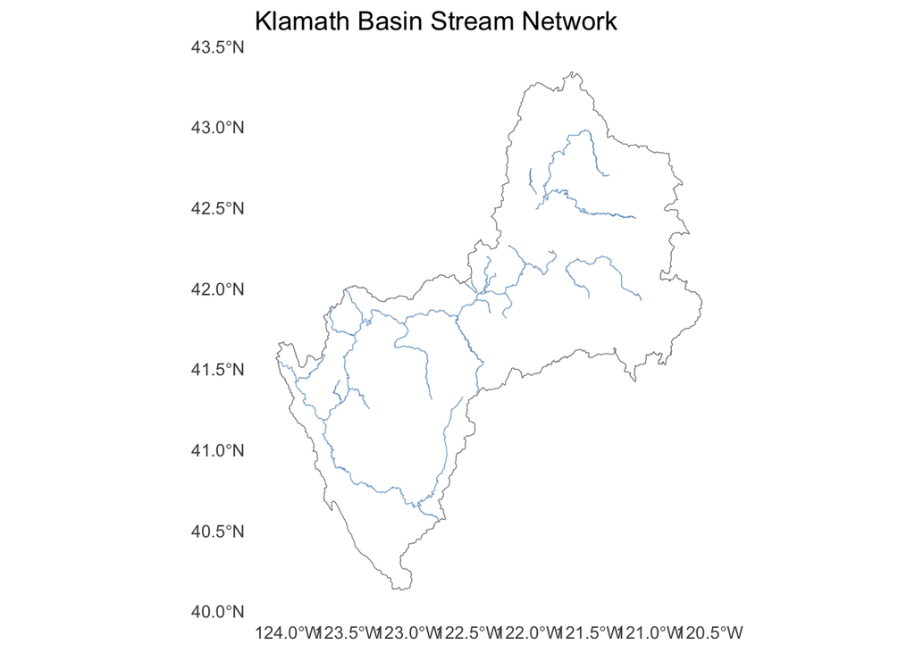

NHDPlus stream network within the Klamath Basin study area.

### Estimated Discharge

Mean annual discharge is estimated from cumulative upstream drainage area using a regional power-law regression:

$$Q = 0.028 \cdot A^{0.89}$$

where $A$ is total drainage area in km². Because Chinook suitability is 1.0 for any discharge ≥ 3 m³/s, a more precise discharge estimate is unlikely to alter IP classifications substantially for the larger named reaches.

### Bankfull Width

Bankfull width is estimated with the Bieger et al. (2015) regional equation:

$$W_{bf} = 2.76 \cdot
A^{0.399}$$

where $A$ is total drainage area (km²). Bankfull width enters the IP model indirectly as the denominator of the valley width index.

### Valley Bottom Width

Valley bottom width is derived from a 12-m DEM using the slope-cutoff method: raster cells with slope < 14.04° (tan⁻¹(0.25)) are classified as valley bottom, and mean width is measured via perpendicular transects along each reach flowline. The methodology follows the [South Fork Eel River Basin Geomorphic Classification](https://watermanagement.ucdavis.edu/download_file/view_inline/144) and the implementation in habistat.

Valley-width calculations are computationally intensive and have been pre-computed in batches. The chunk below is retained for reproducibility but is not evaluated during rendering.

### Valley Width Index

The valley width index (VWI) is the ratio of valley bottom width to bankfull channel width:

$$VWI =
\frac{W_{valley}}{W_{bf}}$$

VWI serves as a proxy for lateral confinement: values < 1 indicate a fully confined channel; values > 4 indicate an unconfined, laterally mobile channel where gravel recruitment and retention are favorable.

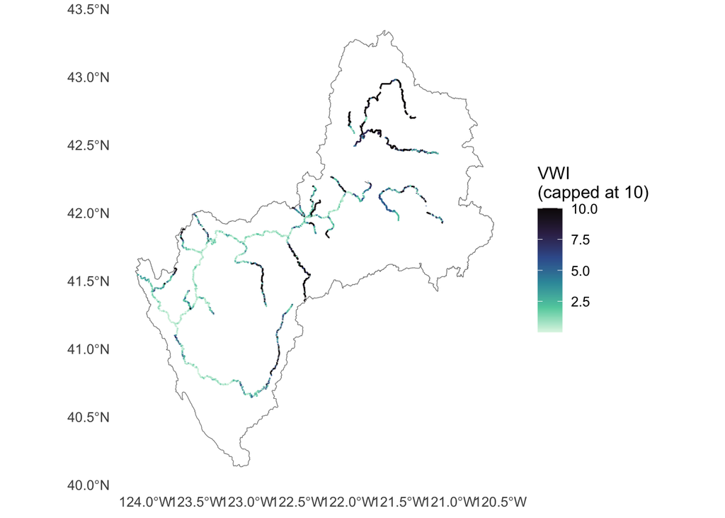

Valley Width Index summary by stream.

| gnis_nm | Min | Median | Mean | Max | % Missing |
| --- | --- | --- | --- | --- | --- |
| Blue Creek | 0.2 | 3.0 | 5.2 | 86.4 | 25 |
| Bogus Creek | 1.1 | 2.9 | 6.3 | 38.4 | 26 |
| Camp Creek | 0.1 | 2.5 | 3.3 | 24.1 | 31 |
| Clear Creek | 0.4 | 1.8 | 4.7 | 47.0 | 24 |
| Fall Creek | 1.5 | 26.1 | 36.2 | 138.0 | 8 |
| Indian Creek | 0.5 | 3.2 | 4.1 | 16.8 | 24 |
| Jenny Creek | 0.2 | 2.1 | 3.1 | 22.6 | 25 |
| Klamath River | 0.0 | 0.7 | 1.0 | 8.5 | 21 |
| Link River | 2.9 | 3.9 | 3.9 | 4.9 | 33 |
| Lost River | 0.0 | 3.7 | 4.2 | 14.7 | 28 |
| Salmon River | 0.2 | 0.9 | 1.5 | 7.2 | 20 |
| Scotch Creek | 0.1 | 4.3 | 9.7 | 139.1 | 26 |
| Scott River | 0.0 | 2.1 | 3.9 | 24.0 | 27 |
| Shasta River | 0.2 | 7.4 | 10.5 | 41.0 | 20 |
| Shovel Creek | 0.6 | 2.7 | 24.8 | 198.6 | 8 |
| Spencer Creek | 1.4 | 6.5 | 8.2 | 29.6 | 8 |
| Sprague River | 0.2 | 4.3 | 5.0 | 13.1 | 19 |
| Trinity River | 0.1 | 1.3 | 2.6 | 24.0 | 26 |
| Williamson River | 0.7 | 12.4 | 19.6 | 196.5 | 21 |
| Wood River | 0.8 | 6.5 | 11.3 | 60.9 | 25 |

## Suitability Criteria

Suitability scores are expressed on a continuous 0–1 scale (1 = fully suitable, 0 = unsuitable). Thresholds are drawn from Agrawal et al. 2005.

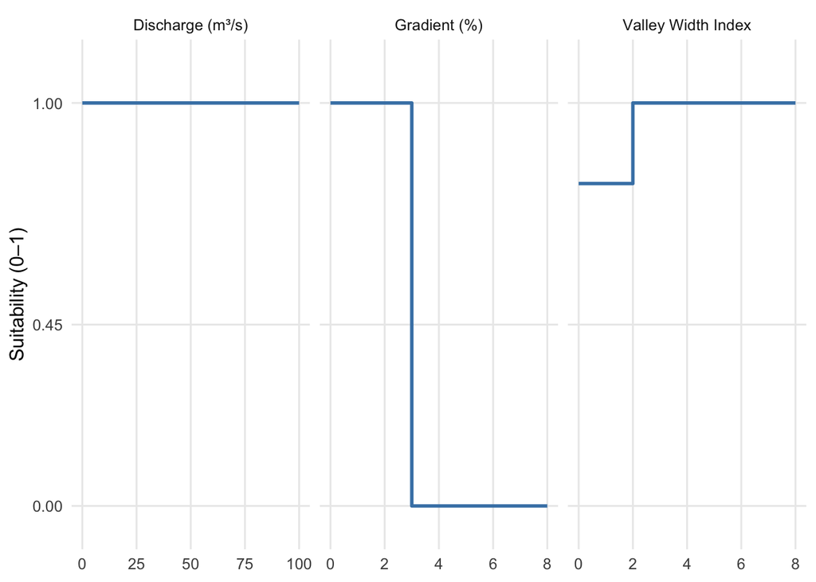

Suitability step functions for gradient (%), discharge (m³/s), and valley width index used in the IP model.

## Population Units

Based on Williams et al. 2006, table 2. Tributaries not explicitly delineated in Table 2 are incorporated into the framework by nesting them within the population unit of the mainstem reach they enter. To determine which population unit a tributary belongs to, the Table 2 boundary descriptions are used. For example, a tributary entering the Klamath River between Portuguese Creek and Spencer Creek would fall within the Upper Klamath River unit (15c), while one entering between the Trinity River confluence and Portuguese Creek would fall within the Middle Klamath River unit (15b).

Note that we added a population unit above Upper Klamath Lake that was not captured in Williams et al. 2006.

## Intrinsic Potential

### Method

Following Bjorkstedt et al. (2005), the reach-level IP score is the geometric mean of the three suitability scores:

$$IP_{reach} = \left(S_{gradient} \times
S_{discharge} \times S_{confinement}\right)^{1/3}$$

The geometric mean gives the model the structure of a limiting-factors analysis: very low suitability on any single variable greatly reduces or eliminates the probability of suitable habitat, regardless of how favorable the other two variables are.

At the watershed scale, IP is summarized as IP-km — the length-weighted sum of reach-level scores:

$$IP\text{-}km = \sum_{i} L_i \times
IP_{reach,i}$$

where $L_i$ is the length of reach $i$ in kilometers. IP-km describes a watershed in terms of its expected equivalent length of continuous high-quality habitat: a watershed with 30 IP-km does not necessarily have 30 km of uniformly excellent habitat, but the weighted integral of lower-quality habitat sums to what would be expected from 30 km of optimal habitat (Bjorkstedt et al. 2005).

> **Note:** All reaches are currently treated as accessible to anadromy. Once a barrier/passage layer is available, the IP-km sum should be restricted to accessible reaches.

### Reach-scale Results

IP_reach distribution by stream (geometric mean of gradient, discharge, and valley confinement suitabilities).

| gnis_nm | Reaches | Min | Median | Mean | Max |
| --- | --- | --- | --- | --- | --- |
| Sprague River | 137 | 0.88 | 1.00 | 0.99 | 1.00 |
| Wood River | 40 | 0.96 | 0.99 | 0.99 | 1.00 |
| Link River | 2 | 0.96 | 0.98 | 0.98 | 1.00 |
| Williamson River | 73 | 0.67 | 1.00 | 0.98 | 1.00 |
| Lost River | 159 | 0.62 | 1.00 | 0.97 | 1.00 |
| Klamath River | 911 | 0.00 | 0.94 | 0.92 | 1.00 |
| Scott River | 226 | 0.00 | 0.94 | 0.90 | 1.00 |
| Salmon River | 92 | 0.00 | 0.94 | 0.88 | 1.00 |
| Trinity River | 686 | 0.00 | 0.95 | 0.88 | 1.00 |
| Jenny Creek | 82 | 0.00 | 0.92 | 0.83 | 1.00 |
| Shasta River | 117 | 0.00 | 0.94 | 0.83 | 1.00 |
| Spencer Creek | 57 | 0.00 | 0.92 | 0.73 | 1.00 |
| Indian Creek | 84 | 0.00 | 0.81 | 0.59 | 1.00 |
| Fall Creek | 35 | 0.00 | 0.69 | 0.53 | 1.00 |
| Blue Creek | 118 | 0.00 | 0.72 | 0.52 | 1.00 |
| Clear Creek | 104 | 0.00 | 0.60 | 0.47 | 1.00 |
| Bogus Creek | 31 | 0.00 | 0.59 | 0.41 | 0.94 |
| Camp Creek | 150 | 0.00 | 0.00 | 0.36 | 1.00 |
| Scotch Creek | 52 | 0.00 | 0.00 | 0.22 | 1.00 |
| Shovel Creek | 33 | 0.00 | 0.00 | 0.20 | 0.71 |

### Watershed-scale Results (IP-km)

IP-km by stream: expected equivalent length of continuous high-quality habitat (Bjorkstedt et al. 2005).

| gnis_nm | IP-km | Total length (km) | Mean IP_reach | Reaches |
| --- | --- | --- | --- | --- |
| Klamath River | 341.7 | 366.3 | 0.92 | 911 |
| Trinity River | 208.2 | 234.1 | 0.88 | 686 |
| Williamson River | 144.3 | 147.3 | 0.98 | 73 |
| Sprague River | 122.9 | 123.6 | 0.99 | 137 |
| Lost River | 106.9 | 108.6 | 0.97 | 159 |
| Scott River | 77.0 | 83.4 | 0.90 | 226 |
| Shasta River | 74.8 | 85.6 | 0.83 | 117 |
| Wood River | 31.7 | 32.0 | 0.99 | 40 |
| Salmon River | 25.1 | 28.1 | 0.88 | 92 |
| Jenny Creek | 22.2 | 32.4 | 0.83 | 82 |
| Blue Creek | 15.6 | 35.4 | 0.52 | 118 |
| Clear Creek | 14.8 | 35.6 | 0.47 | 104 |
| Indian Creek | 14.6 | 25.2 | 0.59 | 84 |
| Spencer Creek | 13.7 | 20.6 | 0.73 | 57 |
| Camp Creek | 11.9 | 34.7 | 0.36 | 150 |
| Fall Creek | 10.2 | 19.6 | 0.53 | 35 |
| Bogus Creek | 8.4 | 18.1 | 0.41 | 31 |
| Shovel Creek | 2.7 | 24.4 | 0.20 | 33 |
| Scotch Creek | 1.9 | 12.7 | 0.22 | 52 |
| Link River | 0.9 | 0.9 | 0.98 | 2 |

### IP by Population Unit

Geospatially define population units for the Klamath Rive, based on table 2 of Williams et al. 2006

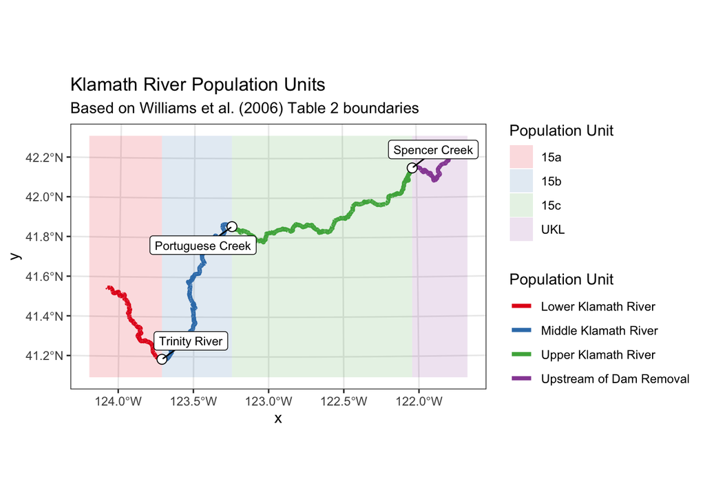

Geospatially define population units for the Trinity River, based on table 2 of Williams et al. 2006

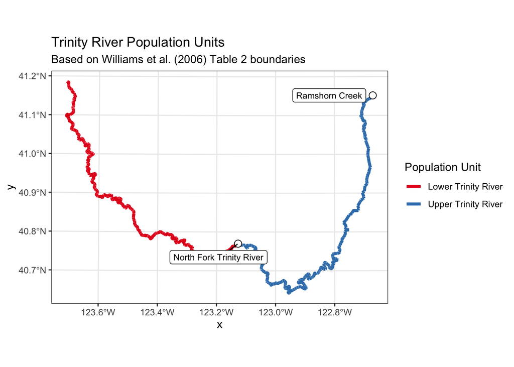

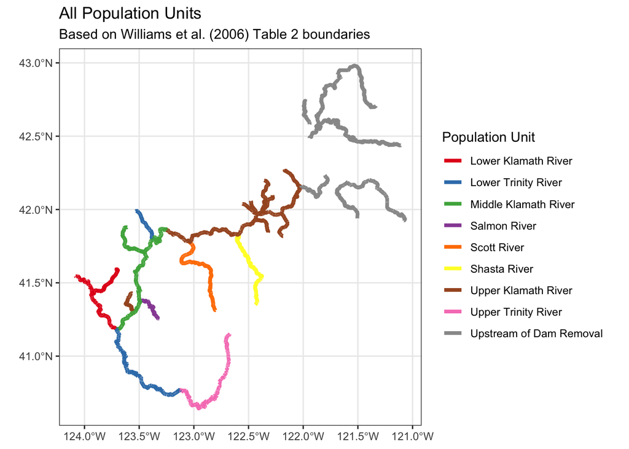

IP-km by population unit: expected equivalent length of continuous high-quality habitat in each population unit (Bjorkstedt et al. 2005, Williams et al. 2006).

| population_unit | IP-km | Total length (km) | Mean IP_reach | Reaches |
| --- | --- | --- | --- | --- |
| Upstream of Dam Removal | 444.8 | 506.9 | 0.98 | 595 |
| Upper Klamath River | 204.7 | 334.0 | 0.68 | 1036 |
| Middle Klamath River | 127.0 | 179.8 | 0.82 | 595 |
| Lower Trinity River | 111.9 | 149.0 | 0.85 | 557 |
| Upper Trinity River | 102.2 | 124.4 | 0.94 | 387 |
| Scott River | 77.0 | 92.7 | 0.90 | 309 |
| Shasta River | 74.8 | 95.8 | 0.83 | 147 |
| Lower Klamath River | 73.5 | 109.4 | 0.76 | 329 |
| Salmon River | 25.1 | 31.5 | 0.88 | 115 |

### Map

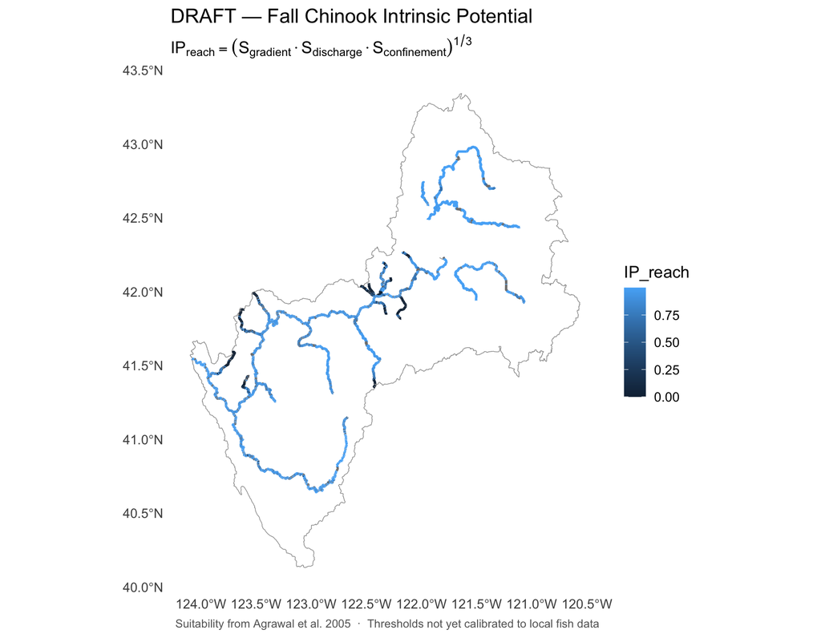

### Save data

Save data as `chinook_ip`

```
## Rows: 24
## Columns: 6
## $ river                 <chr> "blue creek", "bogus creek", "camp creek", "clea…
## $ population_unit       <chr> "lower klamath river", "upper klamath river", "u…
## $ ip_km                 <dbl> 15.6, 8.4, 11.9, 14.8, 10.2, 14.6, 22.2, 57.9, 1…
## $ total_reach_length_km <dbl> 35.4, 18.1, 34.7, 35.6, 19.6, 25.2, 32.4, 60.1, …
## $ ip_mean               <dbl> 0.52, 0.41, 0.36, 0.47, 0.53, 0.59, 0.83, 0.95, …
## $ n_reaches             <int> 118, 31, 150, 104, 35, 84, 82, 142, 351, 369, 49…
```